# Final Project

The Steve Henle, Hazel John, and Jim Schlough Group

April 28, 2016

# A Study of the Data Provided by the Donors Choose Organization

by Steve Henle Hazel John Jim Schlough

## Overview and Motivation

Funding the contemporary K-12 classroom is greatly challenging and many teachers believe that resources provided are insufficient in meeting the most basic objectives. Nontraditional support is playing an increasingly important part in supporting the modern classroom.

The Donors Choose web platform provides a mechanism of providing support to teachers by benefactors. A potential donor may read an appeal written by a teacher to fulfill a specific classroom material need, and donates towards their funding goal. If the funding goal is met, these materials are sourced by fulfillment sources under the control of the Donors Choose organization, and sent directly to the school.

Given the changes in public sentiments and commitments towards financial support of the community school over the past few decades, the ability to raise funds directly into the classroom might come to be considered a vital skill of the teacher in supporting classroom activities.

When written appeals succeed by becoming fully funded, or fail by expiring, the data surrounding the appeal is gathered and made publicly available. By analyzing this data, it might be possible to better understand the factors correlated with success or failure of a written appeal. Some factors such as location, date and time, and poverty level are beyond the control of a teacher. Other factors, such as the written content of an appeal, or to a lesser extent, the credentials of the teacher, can be controlled.

We wish to apply statistical analysis of the available data in an effort to go beyond axiomatic and aesthetic beliefs regarding what makes a more or less effective funding proposal.

back to top

## Related Work

Jim’s sister is a grade school art teacher who successfully funded a 3D printer for her classroom. On last report, the best expert for this printer is a female 4th grader.

Steve writes grant proposals, so it is interesting to understand what makes a good grant proposal by way of a data analysis.

Hazel works with her marketing department on content marketing, personalization etc. She in interested in understanding what motivates prospects to become customers. In this case we analyze factors that encourage prospects to turn into benefactors.

Stephen Colbert made the news in 2015 [by funding every teacher’s proposal for the State of South Carolina](http://time.com/3850694/stephen-colbert-funds-every-teacher-requested-grant-in-south-carolina-schools/). This did rise the national profile of Donors Choose, not only helping all the teachers in South Carolina, but also giving much needed publicity to this cause.

back to top

## Initial Questions

We set forth to answer the following questions regarding the funding proposals for Donors Choose.

*What makes the difference between a proposal that is funded and one that expires?*  
Which are the winning qualities?  
*Of the predicting qualities, are there any that are under the control of the writer?*  
Does the content of the written essay matter?

back to top

## Data

We are using the data made publicly available on the Donors Choose website. This publicly available comes in the form of downloadable csv files, ranging in size from megabytes to gigabytes. This data can be found at [here](http://data.donorschoose.org/open-data/overview/).

The proposals are one element in the open data set published from the Donors Choose web site. An image of the schema showing the suggested recomposition is in Appendix B, below, and can also be found at Donors Choose.  
back to top

### Data Wrangling

back to top

#### Step 1: Data Download & Cleanup

Our first task was to download the data, clean it up and extract the data we needed. We decided to do the analysis with just the data from 2014, so the final task was the filter out unneeded data.

back to top

#### rm_old: Our First Data Wrangling Utility

Our first plan was to use a combination of AWK and SED to do the necessary data cleanup, but time & date fields proved to be problematic. After an evening of steady efforts along those lines, a C++ data cleaning application was written as a stop gap measure. This C++ data cleaner provided a temporary means to separate the 2014 projects records from the csv file and get the rest of the team started with the data. The source code for the intermediate c++ application, was named rm_old and its source code can be found here in Appendix A.  
back to top

### Data Wrangling in R

During analysis of the data files retrieved from the Donor’s Choose website, we noticed that it contained string fields with special characters that caused errors when using the standard read utilities for comma delimited files. The first plan was to read files line by line and use “gsub” to removed unnecessary characters, but this turned out very slow. We then tried to run the UNIX utility “sed” within the “pipe” function, but the special characters like ctrl-M made that problematic. The final iteration still used “sed” by was run as a system call from R. Each file required slight variations in the search patterns so different _clnup.sed scripts were created for each.

Our final data wrangling consisted of the following steps:

- Data download from the website,
- Cleanup via “sed” with a system call
- Extraction of CSV as a dataframe
- Filtering out projects not posted in 2014
- Storing cleaned dataframes as RDS files

back to top

#### Step 2: Data Upload from disk

A simple function was written to upload the cleaned data from RDS files stored on disk. All data exploration and analysis was run on the uploaded data.

back to top

## Exploratory Analysis

We began an exploration of the data to see what relationships might be discovered within it, to compare the completed and expired projects.

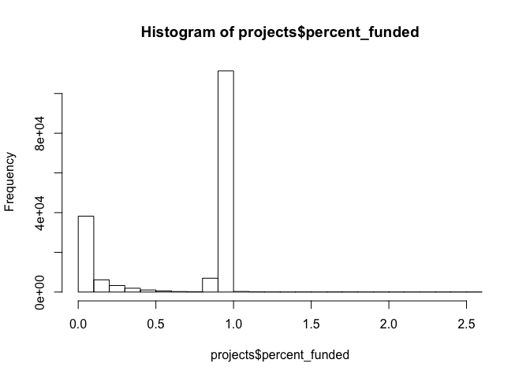

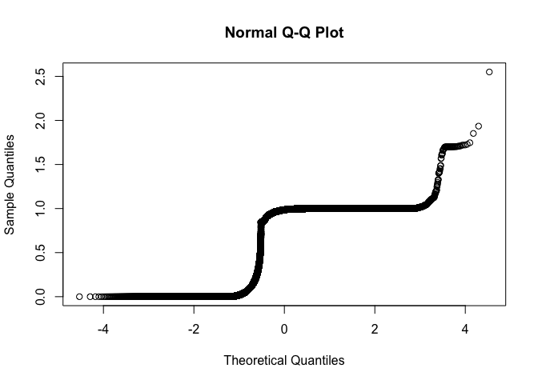

```
## [1] "Data is nowhere near normal, looks like logistic analysis of funded vs non-funded make much more sense."
```

[output not shown]

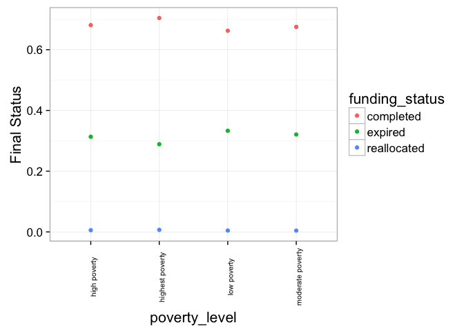

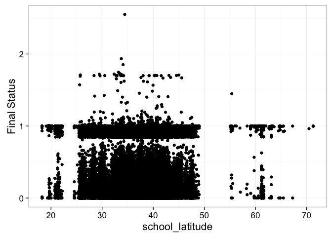

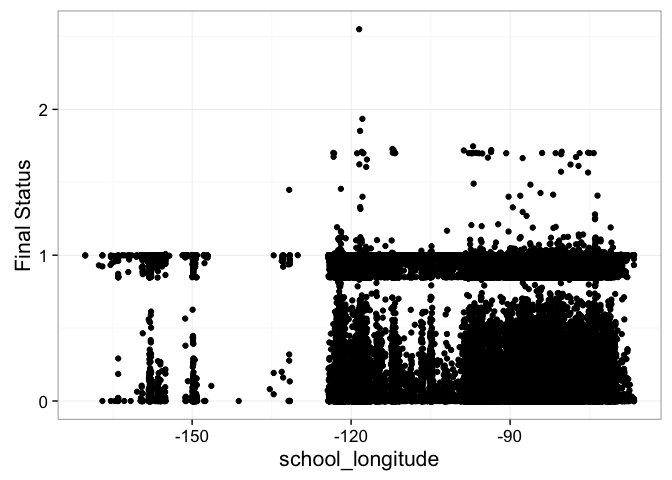

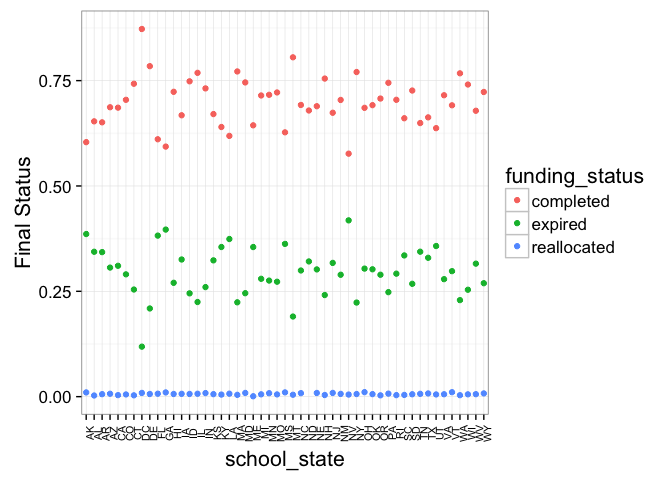

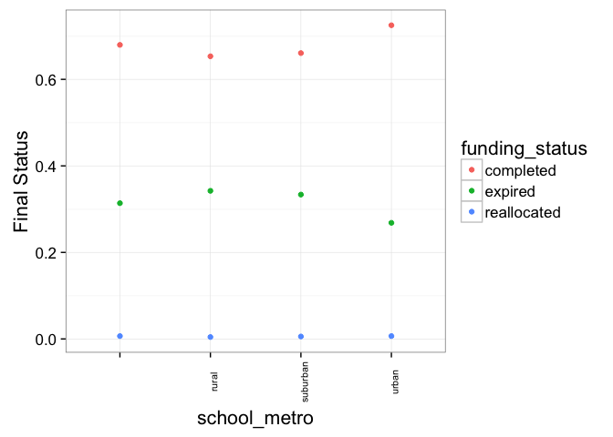

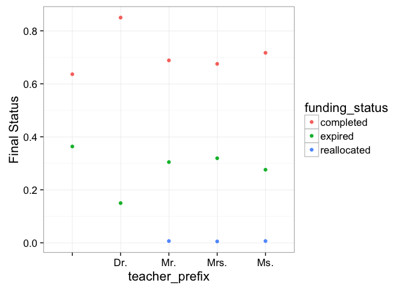

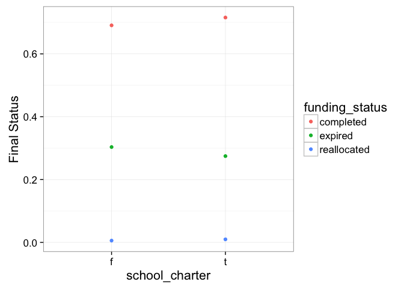

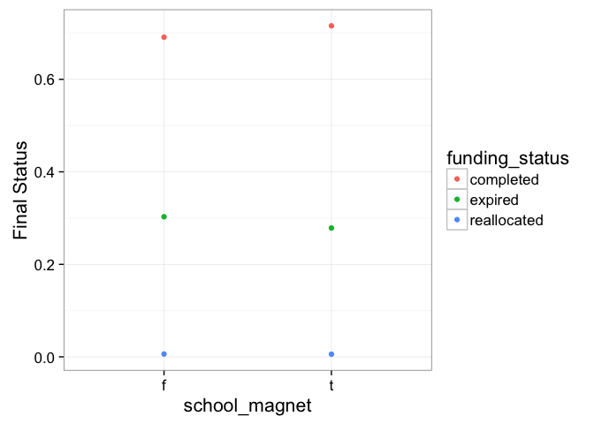

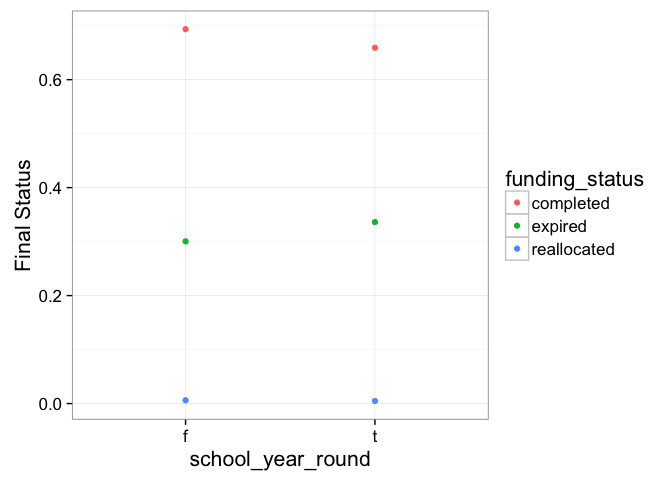

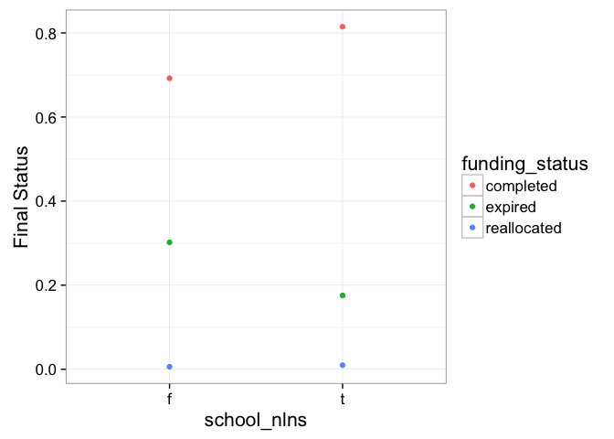

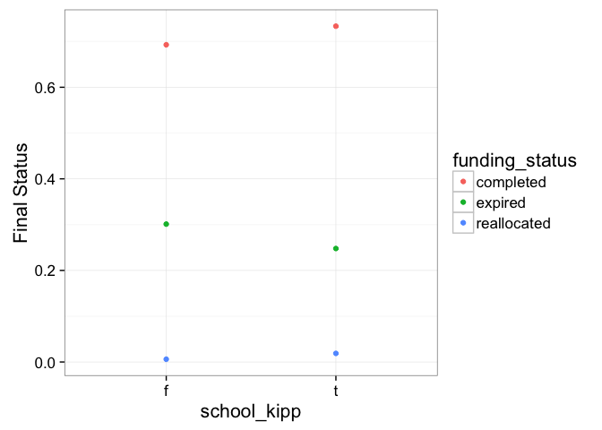

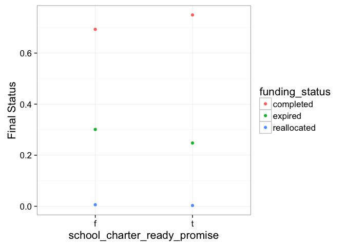

[11 more figures not shown]

#### Building a Prediction Model for Proposal Success

The first attempt to build a model was to use the glm method in the train function and select several variables from the earlier exploratory analysis that looked to have an effect. These variables included: amount of money asked for, school state, primary focus, primary subject, resource type, date posted. We used glm because our outcome is either funded or not funded and glm works well for logistic regression.

```
## Generalized Linear Model
##
## 170326 samples
##     45 predictor
##
## No pre-processing
## Resampling: Bootstrapped (25 reps)
## Summary of sample sizes: 170320, 170320, 170320, 170320, 170320, 170320, ...
## Resampling results:
##
##   RMSE       Rsquared
##   0.4396128  0.09132495
##
##
```

```
## Generalized Linear Model
##
## 133860 samples
##     45 predictor
##
## No pre-processing
## Resampling: Bootstrapped (25 reps)
## Summary of sample sizes: 133855, 133855, 133855, 133855, 133855, 133855, ...
## Resampling results:
##
##   RMSE       Rsquared
##   0.4428837  0.0920202
##
##
```

```
## Generalized Linear Model
##
## 133860 samples
##     45 predictor
##
## No pre-processing
## Resampling: Bootstrapped (25 reps)
## Summary of sample sizes: 133860, 133860, 133860, 133860, 133860, 133860, ...
## Resampling results:
##
##   RMSE       Rsquared
##   0.4469327  0.07612293
##
##
```

```
## Generalized Linear Model
##
## 133860 samples
##     45 predictor
##
## No pre-processing
## Resampling: Bootstrapped (25 reps)
## Summary of sample sizes: 133860, 133860, 133860, 133860, 133860, 133860, ...
## Resampling results:
##
##   RMSE       Rsquared
##   0.4478903  0.07179594
##
##
```

back to top

#### Text Analysis

##### Word Selection Analysis

As part of the data available from the DonorsChoose website, we were able to download the full text of the teacher-written requests accompanying all classroom projects. The heart of each teacher’s classroom project request is their written request, and we wanted to use text mining to see if we could extract information from the essays to predict which projects get funded. The two questions we chose to answer were:

- Does the sentiments expressed in the essay help predict whether it gets funded completed or not?
- Are there specific words that appear in the essays for projects that are fully funded, that don’t appear in the incompletely funded ones?

**Sentiment Analysis**

We started by tokenizing the essay words and then using the sentiment lexicon from “nrc” to assign sentiments to the words. We then computed the percentage occurance for the sentiments in essays grouped by the funding status of the projects and compared.

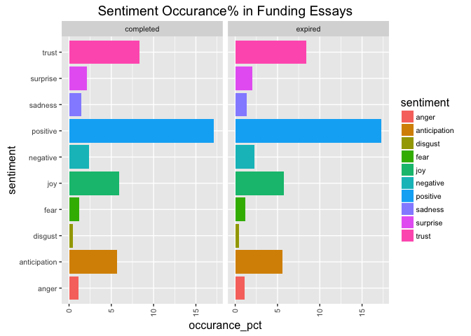

We can see from the graph that both positive and negitive sentiments occur at an almost identical rate completed funded as well as expired projects. We can see the minor differences more clearly in the data frame.

```
## Source: local data frame [11 x 3]
##
##       sentiment  completed    expired
##           (chr)      (dbl)      (dbl)
## 1         anger  1.1026375  1.0838772
## 2  anticipation  5.6380648  5.5864252
## 3       disgust  0.4495098  0.4131162
## 4          fear  1.2389231  1.2130671
## 5           joy  5.9211053  5.7905396
## 6      negative  2.3453001  2.2955258
## 7      positive 17.0967005 17.3146193
## 8       sadness  1.4367613  1.3943689
## 9      surprise  2.0834330  2.0215808
## 10        trust  8.3226758  8.4123286
## 11           NA 54.3648887 54.4745512
```

**Word Analysis**

We then analyzed the occurance of specific words in the essays for insights. We started by looking at the top 10 words for both fully funded and expired projects.

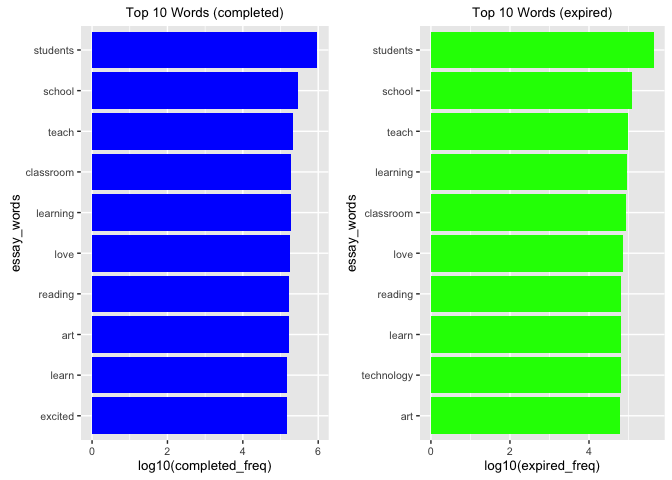

The top 10 words for both categories were almost identical. The only thing that stood out a little was that “excited” was in the top ten for completed funded projects versus “technology” for expired projects. This could be related to the fact that technology is more expensive and thus there is a lower chance of the project getting fully funded.

We removed the common words for both project categories for the top 10 words to focus of the rest of the words.

We then used wordclouds to compare the words that occur the most in both funding categories. We started with high frequency words in essays for projects that were fully funded.

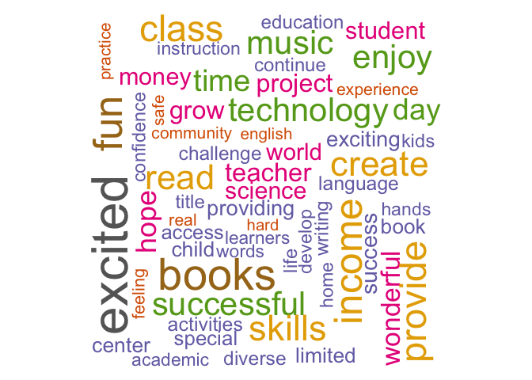

Then we compared it with the high frequency words in essays for projects that expired and weren’t fully funded.

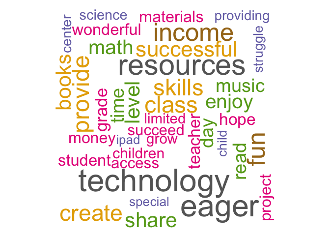

Looking at the wordcloud, one of the things that stood out were the higher relative prominence of “books” for funded projects versus “technology” for expired projects.

back to top

#### Essay Length Analysis: Comparing the word count for completed vs expired projects

Essay Word Counts

| project_count_2014 | 170326 |
| --- | --- |
| completed_project_count_2014 | 118039 |
| completed_project_mean_word_count | 302 |
| completed_project_sd_word | 84 |
| expired_project_count_2014 | 51246 |
| expd_total_word_sums_count | 51245 |
| expd_total_word_sums_mean | 305 |
| expd_total_word_sums_sd | 86 |

back to top

##### Essay word count comparison results

Does essay word count matter?

Here we look at the number of words in essays, to see if there is any significant difference between the number of words in completed and expired essays.

```
## [1] "On average, completed essays had essay word counts that were 2.9918 shorter than expired ones"
```

The length of essay, in terms of word count, does not seem to matter much all by itself.

back to top

## Appendices

### Appendix A: rm_old Source Code

The original source code of the stop gap c++ data cleaning application is below.  
####c++ Source code for rm_old

```r
//
//  main.cpp
//  rm_old
//
//  Created by Jim Schlough on 4/22/16.
//  Copyright © 2016 Jim Schlough. All rights reserved.
//

#include <iostream>
#include <fstream>    // for ifstream, ofstream

#include <string>
#include <ctime>
#include <cstdlib>
#include <stdio.h>    // for tmpnam, remove

// for time & date processing:
#include <sstream>
#include <locale>
#include <iomanip>

using namespace std;

int main(int argc, const char * argv[]) {

    // insert code here...
    if (argc< 3 )
    {
        std::cout << "Usage rm_old fileInName bottomCutOffDate topCutOffDate dateFieldIndex" << endl;
        std::cout << endl;
        std::cout << "   dateFieldIndex is ONE based" << endl;
    }

    char filebuf [L_tmpnam];
    ::strcpy(filebuf, argv[1]);

    std::string outFileName;

    int dateFieldIdx = 0;
    dateFieldIdx = std::atoi(argv[4])-2;


    // TODO: check for clean cutOffDateInput here
    int64_t bottomCutOffDateValue = 0L, topCutOffDateValue = 0L;
    bottomCutOffDateValue = std::atol(argv[2]);
    topCutOffDateValue = std::atol(argv[3]);

    // TODO: check for valid (positive integer) date field index (1 based) here


    std::ifstream inputFile (filebuf, std::ios::in);
    outFileName.append(filebuf);
    outFileName.erase( outFileName.find(".csv"),4);
    outFileName.append("_output.csv");

    std::ofstream outputFile (outFileName, std::ios::out);
    std::string line, submittedDateTimeStr, submittedDateStr;
    bool skipFirst = true;

    if (inputFile.is_open())
    {
        std::getline(inputFile, line);
        skipFirst = (line.find('\"') == std::string::npos); // first line is  header


        while( inputFile)
        {
            if (skipFirst)
            {
                skipFirst = false;
                outputFile << line << endl;
            }
            else std::getline(inputFile, line);

            if (line.length() < 2) continue;
            size_t numberCommas = std::count(line.begin(), line.end(), ',');
            if (numberCommas < 43 ||
                line.find("\"") == std::string::npos ) // skip the header line, which has no "
                continue;

            // find the position of the date in the 41st field
            int x = 0;
            //std::string::size_type
            int lastPos=0, startOfDatePos = 0, endOfDatePos = 0;
            int64_t dateIntValue = 0L;

            // TODO: make magical 39 to be dateFieldIndex in future refinement

            while (x<43   &&  inputFile.good() ) {
                lastPos = (int)line.find(',', lastPos+1);
                if (x== (dateFieldIdx)) // date we seek is in the 41st field
                {
                    startOfDatePos = lastPos+2;
                } else if (startOfDatePos != 0)
                {
                    endOfDatePos = (int)line.find(',', startOfDatePos)-1; // ", is end of field, so -1 for " part
                    break;
                }
                x++;
            }

            submittedDateTimeStr = line.substr(startOfDatePos, endOfDatePos-startOfDatePos );  ///19);

            // truncate the hours, minutes and seconds off of the date
            submittedDateStr = submittedDateTimeStr.substr(0, submittedDateTimeStr.length()-9 );
            while(submittedDateStr.find('-') != std::string::npos )
                submittedDateStr = submittedDateStr.erase( submittedDateStr.find('-'), 1);
            dateIntValue = std::atol(submittedDateStr.c_str());//, std::locale("en_US.utf-8"));

            if (dateIntValue <= bottomCutOffDateValue || dateIntValue >= topCutOffDateValue)
                continue; // skip to the next record if this one is too early or too late

            if (outputFile.is_open())
                outputFile << line << endl;
            else
                exit(EXIT_FAILURE);
        }
        inputFile.close();
        outputFile.close();
    }
    return 0;
}
```

back to top

### Appendix B: The Suggested csv Recomposition Schema

This is schema diagram appears in the Donors Choose web site to serve as a diagram for the recomposition of the csv files:

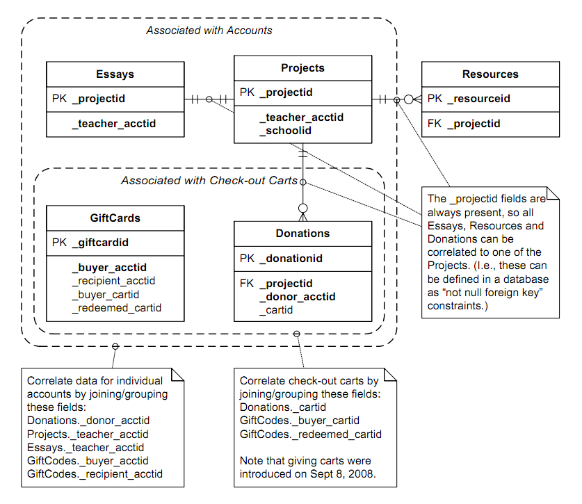

back to top